# Proyecto Interciclo de Inteligencia Artificial

_Por: J. Atariguano L, S. Penaranda J._

Se importan todas las librerias que son necesarias para realizar este proyecto, cada una de ellas es importante pero las más importantes para la creación de la **RNA** son: **Keras** y **TensorFlow**

```python
import os
import re
import numpy as np
import matplotlib.pyplot as pp
%matplotlib inline
from sklearn.model_selection import train_test_split
from sklearn.metrics import classification_report
import keras
from keras.utils import to_categorical
from keras.models import Sequential,Input,Model
from keras.layers import Dense, Dropout, Flatten
from keras.layers.normalization import BatchNormalization
```

[output not shown]

Antes de iniciar debemos cargar los datos que necesitaremos y mediante el método **plt.imread(filepath)** que cargará a memoria en un array todas las imagenes.

```python
dirname = os.path.join(os.getcwd(), 'corpus')
imgpath = dirname + os.sep

images = []
directories = []
dircount = []
prevRoot=''
cant=0

print("leyendo imagenes de ",imgpath)

for root, dirnames, filenames in os.walk(imgpath):
    for filename in filenames:
        if re.search("\.(jpg|jpeg|png|bmp|tiff)$", filename):
            cant=cant+1
            filepath = os.path.join(root, filename)
            image = pp.imread(filepath)
            images.append(image)
            #b = "Leyendo..." + str(cant)
            #print (b, end="\r")
            if prevRoot !=root:
                #print(root, cant)
                prevRoot=root
                directories.append(root)
                dircount.append(cant)
                cant=0
dircount.append(cant)

dircount = dircount[1:]
dircount[0]=dircount[0]+1
print('Directorios leidos:',len(directories))
print("Imagenes en cada directorio", dircount)
print('suma Total de imagenes en subdirs:',sum(dircount))
```

```
leyendo imagenes de  C:\Users\USER\Desktop\Decimo\IA2\Proyecto Integrador\corpus\
Directorios leidos: 46
Imagenes en cada directorio [1701, 1700, 1700, 1700, 1700, 1700, 1700, 1700, 1700, 1700, 1700, 1700, 1700, 1700, 1700, 1700, 1700, 1700, 1700, 1700, 1700, 1700, 1700, 1700, 1700, 1700, 1700, 1700, 1700, 1700, 1700, 1700, 1700, 1700, 1700, 1700, 1700, 1700, 1700, 1700, 1700, 1700, 1700, 1700, 1700, 1…
suma Total de imagenes en subdirs: 78200
```

Crearemos las etiquetas en labels , es decir, le daremos valores de 0 al 45 a cada carpeta, ya que son 46 las carpetas que contienen los datos. Luego convertimos las etiquetas y las imágenes en numpy array con **np.array()**

```python
labels=[]
indice=0
for cantidad in dircount:
    for i in range(cantidad):
        labels.append(indice)
    indice=indice+1
print("Cantidad etiquetas creadas: ",len(labels))

caracteres=[]
indice=0
for directorio in directories:
    name = directorio.split(os.sep)
    #print(indice , name[len(name)-1])
    caracteres.append(name[len(name)-1])
    indice=indice+1

y = np.array(labels)
X = np.array(images, dtype=np.uint8) #convierto de lista a numpy

# Find the unique numbers from the train labels
classes = np.unique(y)
nClasses = len(classes)
print('Total number of outputs : ', nClasses)
print('Output classes : ', classes)
```

```
Cantidad etiquetas creadas:  78200
Total number of outputs :  46
Output classes :  [ 0  1  2  3  4  5  6  7  8  9 10 11 12 13 14 15 16 17 18 19 20 21 22 23
 24 25 26 27 28 29 30 31 32 33 34 35 36 37 38 39 40 41 42 43 44 45]
```

Realizamos el proceso de **One-Hot encoding** con **to_categorical()** que se refiere a convertir las etiquetas o nuestras salidas.

```python
# Change the labels from categorical to one-hot encoding
print('Original label:', y[1701])
y = to_categorical(y)

# Display the change for category label using one-hot encoding

print('After conversion to one-hot:', y[1701])
```

```
Original label: 1
After conversion to one-hot: [0. 1. 0. 0. 0. 0. 0. 0. 0. 0. 0. 0. 0. 0. 0. 0. 0. 0. 0. 0. 0. 0. 0. 0.
 0. 0. 0. 0. 0. 0. 0. 0. 0. 0. 0. 0. 0. 0. 0. 0. 0. 0. 0. 0. 0. 0.]
```

```python
X_train, X_test, y_train, y_test = train_test_split(X, y, test_size = 0.2, stratify = y)
```

Preprocesamos el valor de los pixeles y lo normalizamos para que tengan un valor entre 0 y 1, por eso dividimos en 255.

```python
X_train = X_train.astype('float32')
X_test = X_test.astype('float32')
X_train = X_train / 255.
X_test = X_test / 255.
```

Ahora creamos la **RNA** con dos capas y cada una con su respectiva activación, al cambiar la activación se puede llegar a mejorar o a su vez empeorar la red. Tambien hacemos uso del método **Flatten()** y aplanamos para tener un input de 1024 y no una matriz de 32x32.

```python
model = keras.Sequential([
    keras.layers.Flatten(input_shape=(32, 32)),
    keras.layers.Dense(425, activation='softsign'),
    keras.layers.Dense(nClasses, activation='softmax')
])
```

Luego compilamos nuestra red **model.compile()** y le asignamos un optimizador, un tipo de pérdida y una métrica que también cada uno de estos parámetros influirá a una mejor o peor precisión de la RNA.

```python
model.compile(optimizer='adam',
              loss='binary_crossentropy',
              metrics=['binary_accuracy'])
```

Ahora sí que entrenaremos la red: Indicamos con **model.fit()** las entradas, salidas y la cantidad de iteraciones de aprendizaje (epochs) de entrenamiento.

```python
historial = model.fit(X_train, y_train, validation_data = (X_test, y_test), epochs=4)
```

```
Train on 62560 samples, validate on 15640 samples
```

Por último guardamos la red **YA ENTRENADA** model.save() en un formato de archivo h5 lo que nos permitirá hacer uso de ella SIN necesidad de volver a entrenar

```python
model.save("entrenamiento1.h5")
```

### Resultados

Ya con nuestra red entrenada, ahora la ponemos a prueba con el set de imágenes para test que separamos al principio.

```python
test_eval = model.evaluate(X_test, y_test)
print('Test loss:', test_eval[0])
print('Test accuracy:', test_eval[1])
```

```
Test loss: 0.04393189630049574
Test accuracy: 0.9870337843894958
```

Graficamos la precisión de la RNA

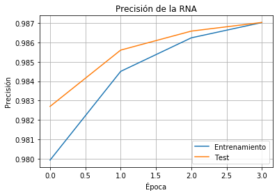

```python
#pp.plot(historial.history['accuracy'])
pp.plot(historial.history['binary_accuracy'])
pp.plot(historial.history['val_binary_accuracy'])
#pp.plot(historial.history['val_accuracy'])
pp.title('Precisión de la RNA')
pp.ylabel('Precisión')
pp.xlabel('Época')
pp.legend(['Entrenamiento','Test'], loc='lower right')
pp.grid(True)
pp.savefig('Presicion.png')
pp.show()
```

Graficamos la pérdida de la RNA

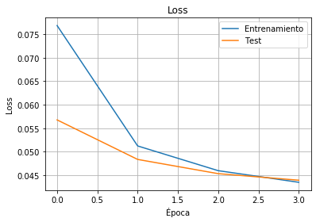

```python
pp.plot(historial.history['loss'])
pp.plot(historial.history['val_loss'])
pp.title('Loss')
pp.ylabel('Loss')
pp.xlabel('Época')
pp.legend(['Entrenamiento','Test'], loc='upper right')
pp.grid(True)
pp.savefig('Perdida.png')
pp.show()
```

Realizamos un predicción para ver como está la red

```python
predictions = model.predict(X_test)
print('class for image 1: ' + str(np.argmax(y_test[3])))
print('predicted:         ' + str(np.argmax(predictions[3])))
```

```
class for image 1: 27
predicted:         27
```

## Segunda red

```python
model2 = keras.Sequential([
    keras.layers.Flatten(input_shape=(32, 32)),
    keras.layers.Dense(1050, activation='elu'),
    keras.layers.Dense(428, activation='sigmoid'),
    keras.layers.Dense(556, activation='softsign'),
    keras.layers.Dense(nClasses, activation='sigmoid')
])
```

```python
model2.compile(optimizer='nadam',
              loss='poisson',
              metrics=['accuracy'])
```

```python
historial2 = model2.fit(X_train, y_train, validation_data = (X_test, y_test), epochs=10)
```

```
Train on 62560 samples, validate on 15640 samples
```

```python
test_eval2 = model2.evaluate(X_test, y_test, verbose=2)
print('Test loss:', test_eval2[0])
print('Test accuracy:', test_eval2[1])
```

```
Test loss: 0.03821309118167214
Test accuracy: 0.8175191879272461
```

```python
from sklearn.metrics import accuracy_score

y_pred2 = model2.predict(X_train)

pred2 = list()
for i in range(len(y_pred2)):
    pred2.append(np.argmax(y_pred2[i]))

test2 = list()
for i in range(len(y_train)):
    test2.append(np.argmax(y_train[i]))
precision2 = accuracy_score(pred2, test2) # Comparamos lo que predijo la red con las salidas deseadas
print('Precisión: ',round((precision2*100),2))
```

```
Precisión:  89.86
```

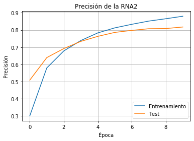

```python
pp.plot(historial2.history['accuracy'])
#pp.plot(historial.history['binary_accuracy'])
#pp.plot(historial.history['val_binary_accuracy'])
pp.plot(historial2.history['val_accuracy'])
pp.title('Precisión de la RNA2')
pp.ylabel('Precisión')
pp.xlabel('Época')
pp.legend(['Entrenamiento','Test'], loc='lower right')
pp.grid(True)
pp.savefig('Presicion2.png')
pp.show()
```

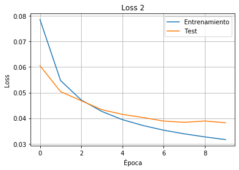

```python
pp.plot(historial2.history['loss'])
pp.plot(historial2.history['val_loss'])
pp.title('Loss 2')
pp.ylabel('Loss')
pp.xlabel('Época')
pp.legend(['Entrenamiento','Test'], loc='upper right')
pp.grid(True)
pp.savefig('Perdida2.png')
pp.show()
```

## Tercera RNA

```python
model3 = keras.Sequential([
    keras.layers.Flatten(input_shape=(32, 32)),
    keras.layers.Dense(1200, activation='relu'),
    keras.layers.Dropout(0.3),
    keras.layers.Dense(200, activation='selu'),
    keras.layers.Dropout(0.3, name='Dropout_Regularization'),
    keras.layers.Dense(nClasses, activation='softmax')
])
```

```python
model3.compile(optimizer='adam',
              loss='categorical_crossentropy',
              metrics=['accuracy'])
```

```python
historial3 = model3.fit(X_train, y_train, validation_data = (X_test, y_test), epochs=10)
```

```
Train on 62560 samples, validate on 15640 samples
```

```python
test_eval3 = model3.evaluate(X_test, y_test, verbose=2)
print('Test loss:', test_eval3[0])
print('Test accuracy:', test_eval3[1])
```

```
Test loss: 0.6956436716077273
Test accuracy: 0.8055626749992371
```

```python
from sklearn.metrics import accuracy_score

y_pred3 = model3.predict(X_train)

pred3 = list()
for i in range(len(y_pred3)):
    pred3.append(np.argmax(y_pred3[i]))

test3 = list()
for i in range(len(y_train)):
    test3.append(np.argmax(y_train[i]))
precision3 = accuracy_score(pred3, test3) # Comparamos lo que predijo la red con las salidas deseadas
print('Precisión: ',round((precision3*100),2))
```

```
Precisión:  88.35
```

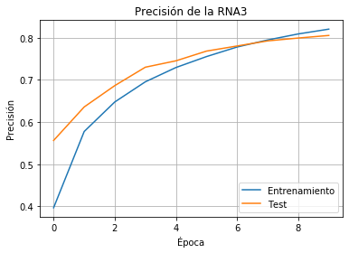

```python
pp.plot(historial3.history['accuracy'])
pp.plot(historial3.history['val_accuracy'])
pp.title('Precisión de la RNA3')
pp.ylabel('Precisión')
pp.xlabel('Época')
pp.legend(['Entrenamiento','Test'], loc='lower right')
pp.grid(True)
pp.savefig('Presicion3.png')
pp.show()
```

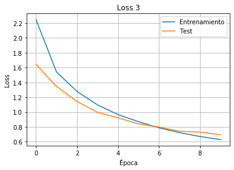

```python
pp.plot(historial3.history['loss'])
pp.plot(historial3.history['val_loss'])
pp.title('Loss 3')
pp.ylabel('Loss')
pp.xlabel('Época')
pp.legend(['Entrenamiento','Test'], loc='upper right')
pp.grid(True)
pp.savefig('Perdida3.png')
pp.show()
```

### Guardamos las dos ultimas RNA

```python
model2.save("entrenamiento2.h5")
model3.save("entrenamiento3.h5")
```

## Creamos nuestras Matrices de confusión usando **Scikit Learn** y la graficamos

Sacamos las predicciones

```python
pred = model.predict(X_test, verbose=1)
predicted = np.argmax(pred, axis=1)
```

```python
pred2 = model2.predict(X_test, verbose=1)
predicted2 = np.argmax(pred2, axis=1)
```

```python
pred3 = model3.predict(X_test, verbose=1)
predicted3 = np.argmax(pred3, axis=1)
```

Creamos dataframes con los valores para la **MATRIZ DE CONFUSIÓN**

```python
from sklearn.metrics import confusion_matrix, classification_report
import pandas as pd
import seaborn as sn
import matplotlib.pyplot as plt
#Creamos la matriz de confusión
cm = confusion_matrix(np.argmax(y_test, axis=1), predicted)

# Visualiamos la matriz de confusión
df_cm = pd.DataFrame(cm, range(nClasses), range(nClasses))
```

```python
from sklearn.metrics import confusion_matrix, classification_report
import pandas as pd
import seaborn as sn
import matplotlib.pyplot as plt
#Creamos la matriz de confusión
cm2 = confusion_matrix(np.argmax(y_test, axis=1), predicted2)

# Visualiamos la matriz de confusión
df_cm2 = pd.DataFrame(cm2, range(nClasses), range(nClasses))
```

```python
from sklearn.metrics import confusion_matrix, classification_report
import pandas as pd
import seaborn as sn
import matplotlib.pyplot as plt
#Creamos la matriz de confusión
cm3 = confusion_matrix(np.argmax(y_test, axis=1), predicted3)

# Visualiamos la matriz de confusión
df_cm3 = pd.DataFrame(cm3, range(nClasses), range(nClasses))
```

Graficamos los dataframe, es decir, las matrices de confusión

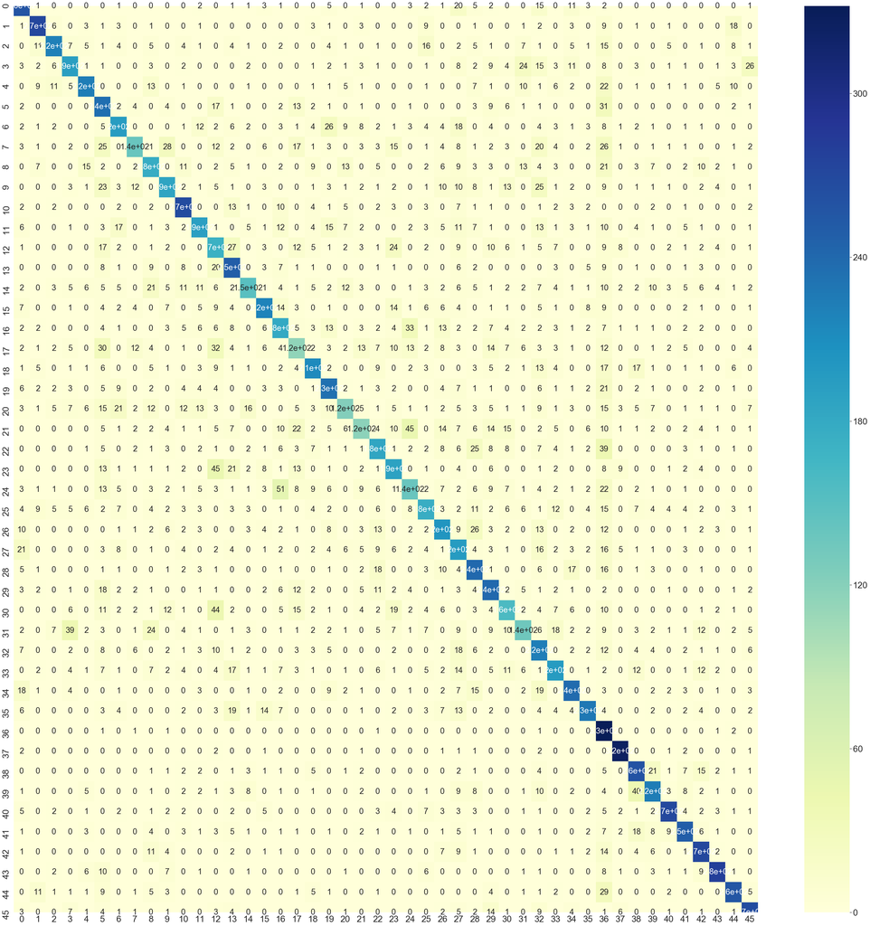

```python
plt.figure(figsize = (50,50))
sn.set(font_scale=2.4) #for label size
sn.heatmap(df_cm, annot=True, annot_kws={"size": 24}, cmap="YlGnBu") # font size
plt.savefig('MatrizConfusion.png')
plt.show()
```

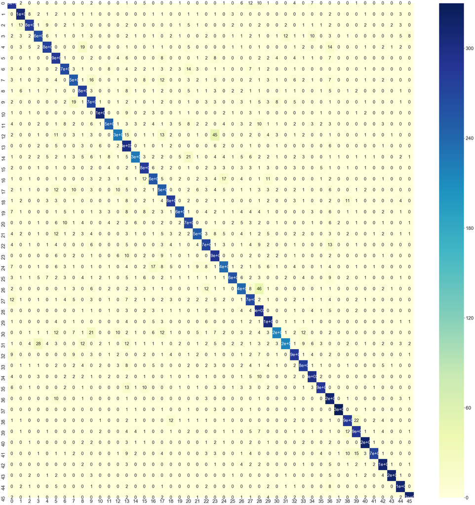

```python
plt.figure(figsize = (50,50))
sn.set(font_scale=2.4) #for label size
sn.heatmap(df_cm2, annot=True, annot_kws={"size": 24}, cmap="YlGnBu") # font size
plt.savefig('MatrizConfusion2.png')
plt.show()
```

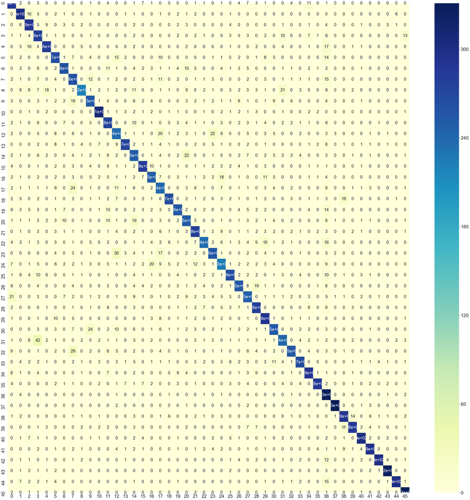

```python
plt.figure(figsize = (50,50))
sn.set(font_scale=2.4) #for label size
sn.heatmap(df_cm3, annot=True, annot_kws={"size": 24}, cmap="YlGnBu") # font size
plt.savefig('MatrizConfusion3.png')
plt.show()
```

Por último mostramos los resportes

```python
report = classification_report(np.argmax(y_test, axis=1), predicted)
print(report)
```

```
              precision    recall  f1-score   support

           0       0.66      0.76      0.71       340
           1       0.80      0.80      0.80       340
           2       0.79      0.65      0.72       340
           3       0.64      0.56      0.60       340
           4       0.78      0.66      0.71       340
           5       0.47      0.69      0.56       340
           6       0.64      0.57      0.60       340
           7       0.71      0.41      0.52       340
           8       0.54      0.52      0.53       340
           9       0.63      0.55      0.59       340
          10       0.73      0.79      0.76       340
          11       0.68      0.56      0.62       340
          12       0.40      0.51      0.45       340
```

[output cut: 37 more lines]

```python
report2 = classification_report(np.argmax(y_test, axis=1), predicted2)
print(report2)
```

```
              precision    recall  f1-score   support

           0       0.76      0.84      0.80       340
           1       0.87      0.91      0.89       340
           2       0.89      0.83      0.86       340
           3       0.81      0.78      0.79       340
           4       0.86      0.81      0.84       340
           5       0.70      0.84      0.76       340
           6       0.85      0.79      0.82       340
           7       0.75      0.74      0.75       340
           8       0.79      0.82      0.81       340
           9       0.72      0.80      0.76       340
          10       0.93      0.91      0.92       340
          11       0.86      0.73      0.79       340
          12       0.83      0.66      0.74       340
```

[output cut: 37 more lines]

```python
report3 = classification_report(np.argmax(y_test, axis=1), predicted3)
print(report3)
```

```
              precision    recall  f1-score   support

           0       0.75      0.84      0.79       340
           1       0.81      0.88      0.85       340
           2       0.78      0.86      0.82       340
           3       0.64      0.82      0.72       340
           4       0.84      0.83      0.83       340
           5       0.76      0.79      0.77       340
           6       0.86      0.77      0.81       340
           7       0.66      0.76      0.71       340
           8       0.89      0.65      0.75       340
           9       0.76      0.74      0.75       340
          10       0.92      0.91      0.91       340
          11       0.73      0.81      0.77       340
          12       0.67      0.70      0.68       340
```

[output cut: 37 more lines]

### Metodo para probar

```python
from skimage.transform import resize

images=[]
# AQUI ESPECIFICAMOS UNAS IMAGENES
filenames = ['./corpus/character_1_ka/1343.png']

for filepath in filenames:
    image = pp.imread(filepath,0)
    image_resized = resize(image, (32, 32),anti_aliasing=True,clip=False,preserve_range=True)
    images.append(image_resized)

X = np.array(images, dtype=np.uint8) #convierto de lista a numpy
X_test = X.astype('float32')
X_test = X_test / 255.

predicted_classes = model.predict(X_test)

for i, img_tagged in enumerate(predicted_classes):
    print(filenames[i], caracteres[img_tagged.tolist().index(max(img_tagged))])
```

```
./corpus/character_1_ka/1343.png character_25_ma
```

```python
from skimage.transform import resize

images2=[]
# AQUI ESPECIFICAMOS UNAS IMAGENES
filenames2 = ['./corpus/character_1_ka/1343.png']

for filepath2 in filenames2:
    image2 = pp.imread(filepath2,0)
    image2_resized = resize(image2, (32, 32),anti_aliasing=True,clip=False,preserve_range=True)
    images2.append(image2_resized)

X2 = np.array(images2, dtype=np.uint8) #convierto de lista a numpy
X2_test = X2.astype('float32')
X2_test = X2_test / 255.

predicted_classes2 = model2.predict(X2_test)

for i2, img_tagged2 in enumerate(predicted_classes2):
    print(filenames2[i], caracteres[img_tagged2.tolist().index(max(img_tagged2))])
```

```
./corpus/character_1_ka/1343.png character_30_motosaw
```

```python
from skimage.transform import resize

images3=[]
# AQUI ESPECIFICAMOS UNAS IMAGENES
filenames3 = ['./corpus/character_1_ka/1343.png']

for filepath3 in filenames3:
    image3 = pp.imread(filepath3,0)
    image3_resized = resize(image2, (32, 32),anti_aliasing=True,clip=False,preserve_range=True)
    images3.append(image3_resized)

X3 = np.array(images3, dtype=np.uint8) #convierto de lista a numpy
X3_test = X3.astype('float32')
X3_test = X3_test / 255.

predicted_classes3 = model3.predict(X3_test)

for i3, img_tagged3 in enumerate(predicted_classes3):
    print(filenames3[i], caracteres[img_tagged3.tolist().index(max(img_tagged3))])
```

```
./corpus/character_1_ka/1343.png character_1_ka
```

## Creamos un reporte de tipo PDF con todos los resultados

```python
from reportlab.pdfgen import canvas
from reportlab.lib.pagesizes import A4
c = canvas.Canvas("ProyectoInterciclo-AtariguanoJose_PenarandaS.pdf", pagesize=A4)
#Ancho - W, Alto - H
ancho, alto = A4
c.setFont("Times-Roman", 20)
c.drawString(ancho-445, alto - 50, "Universidad Politécnica Salesiana")
c.drawImage('logo.png', ancho-160, alto-68, 50, 50)
c.setFont("Times-Roman", 16)
c.drawString(ancho-575, alto - 95, "Integrantes: José Atariguano, Sandra Peñaranda")
c.setFont("Helvetica-Bold", 14)
c.drawString(ancho-385, alto - 135, "Primer Modelo de la RNA")
c.setFont("Helvetica", 12)
c.drawString(ancho-555, alto - 165, "a. Precisión")
#c.showPage()
c.drawImage('Presicion.png', ancho-490, alto-470, 350, 300)
c.drawString(ancho-555, alto - 485, "b. Pérdida")
c.drawImage('Perdida.png', ancho-490, alto-785, 350, 300)
c.showPage()
c.drawString(ancho-555, alto - 50, "c. Matriz de Confusión")
c.drawImage('MatrizConfusion.png', ancho-660, alto-650, 750, 600)
#########################################################
c.showPage()
c.setFont("Helvetica-Bold", 14)
c.drawString(ancho-385, alto - 50, "Segundo Modelo de la RNA")
c.setFont("Helvetica", 12)
c.drawString(ancho-555, alto - 85, "a. Precisión")
#c.showPage()
c.drawImage('Presicion2.png', ancho-490, alto-390, 350, 300)
c.drawString(ancho-555, alto - 425, "b. Pérdida")
c.drawImage('Perdida2.png', ancho-490, alto-745, 350, 300)
c.showPage()
c.drawString(ancho-555, alto - 50, "c. Matriz de Confusión")
c.drawImage('MatrizConfusion2.png', ancho-660, alto-650, 750, 600)
#########################################################
c.showPage()
c.setFont("Helvetica-Bold", 14)
c.drawString(ancho-385, alto - 50, "Tercer Modelo de la RNA")
c.setFont("Helvetica", 12)
c.drawString(ancho-555, alto - 85, "a. Precisión")
#c.showPage()
c.drawImage('Presicion3.png', ancho-490, alto-390, 350, 300)
c.drawString(ancho-555, alto - 425, "b. Pérdida")
c.drawImage('Perdida3.png', ancho-490, alto-745, 350, 300)
c.showPage()
c.drawString(ancho-555, alto - 50, "c. Matriz de Confusión")
c.drawImage('MatrizConfusion3.png', ancho-660, alto-650, 750, 600)
c.save()
print("Documento guardado")
```

```
Documento guardado
```